# Text Mining using Tidytext

03/29/2018

## The tidy text format

Tidy text format: **a table with one-token-per-row**

Token: a meaningful unit of text that we are interested in using for analysis, such as a word (most commonly used), n-gram, sentence, paragraph

Tidy data sets allow manipulation with a standard set of "tidy" tools, such as `dplyr`, `tidyr`, `ggplot2`, and `broom`

Easily convert to and from non-tidy format objects from popular text mining R packages such as `tm` and `quanteda`

## Contrasting tidy text with other data structures

Tidy text format is a table with **one-token-per-row**. Other ways text is often stored in text mining approaches:

- **String**: character vectors, and often text data is first read into memory in this form
- **Corpus**: These types of objects typically contain raw strings annotated with additional metadata and details
- **Document-term matrix**: This is a sparse matrix describing a collection of documents with one row for each document and one column for each term. The value in the matrix is typically word count or tf-idf

## Converting text to a tidy format

Let us use the data provided in `harrypotter` [package](https://github.com/bradleyboehmke/harrypotter)

For instance, the following illustrates the raw text of the first two chapters of the philosophers_stone:

```r
library(harrypotter)
philosophers_stone[1:2]
```

```
## [1] "THE BOY WHO LIVED　　Mr. and Mrs. Dursley, of number four, Privet Drive, were proud to say that they were perfectly normal, thank you very much. They were the last people you'd expect to be involved in anything strange or mysterious, because they just didn't hold with such nonsense.　　Mr. Dursl…
## [2] "THE VANISHING GLASS　　Nearly ten years had passed since the Dursleys had woken up to find their nephew on the front step, but Privet Drive had hardly changed at all. The sun rose on the same tidy front gardens and lit up the brass number four on the Dursleys' front door; it crept into their l…
```

## Converting text to a tidy format

In order to turn it into a tidy text dataset, we first need to put it into a data frame.

```r
library(dplyr)
text_df <- data_frame(chapter = seq_along(philosophers_stone),
                      text = philosophers_stone)
text_df
```

```
## # A tibble: 17 x 2
##   chapter text
##     <int> <chr>
## 1       1 "THE BOY WHO LIVED　　Mr. and Mrs. Dursley, of number four, Prive~
## 2       2 "THE VANISHING GLASS　　Nearly ten years had passed since the Dur~
## 3       3 "THE LETTERS FROM NO ONE　　The escape of the Brazilian boa const~
## 4       4 "THE KEEPER OF THE KEYS　　BOOM. They knocked again. Dudley jerke~
## 5       5 "DIAGON ALLEY　　Harry woke early the next morning. Although he c~
## 6       6 "THE JOURNEY FROM PLATFORM NINE AND THREE-QUARTERS　　Harry's las~
## # ... with 11 more rows
```

## Converting text to a tidy format

### [unnest_tokens()](https://www.rdocumentation.org/packages/tidytext/versions/0.1.6/topics/unnest_tokens)

```r
library(tidytext)
text_df %>% unnest_tokens(word, text)
```

```
## # A tibble: 77,875 x 2
##   chapter word
##     <int> <chr>
## 1       1 the
## 2       1 boy
## 3       1 who
## 4       1 lived
## 5       1 mr
## 6       1 and
## # ... with 7.787e+04 more rows
```

- strips all punctuation

## Word Frequency

The simplest word frequency analysis is assessing the most common words in text. We can use count() from `dplyr` to assess the most common words in philosophers_stone:

```r
text_df %>%
        unnest_tokens(word, text) %>%
        count(word, sort = TRUE)
```

```
## # A tibble: 5,978 x 2
##   word      n
##   <chr> <int>
## 1 the    3629
## 2 and    1923
## 3 to     1861
## 4 a      1691
## 5 he     1528
## 6 of     1267
## # ... with 5,972 more rows
```

- A lot of the most common words are not very informative

## Word Frequency

We can remove the stop words with anti_join() and the built-in stop_words data set provided by `tidytext`.

```r
text_df %>%
        unnest_tokens(word, text) %>%
        anti_join(stop_words) %>%
        count(word, sort = TRUE)
```

```
## # A tibble: 5,421 x 2
##   word          n
##   <chr>     <int>
## 1 harry      1213
## 2 ron         410
## 3 hagrid      336
## 4 hermione    257
## 5 professor   181
## 6 looked      169
## # ... with 5,415 more rows
```

## Word Frequency

We can visualise top 5 most common words with ggplot()

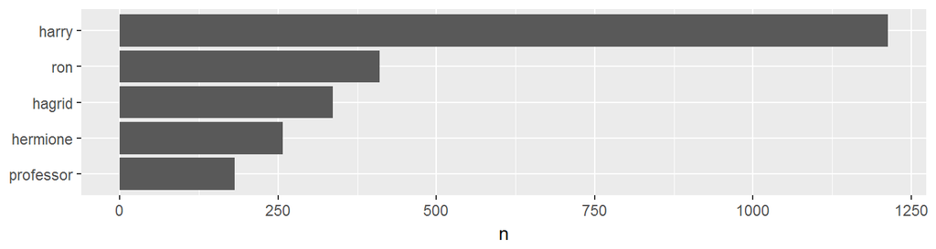

```r
library(ggplot2)
text_df %>%
        unnest_tokens(word, text) %>%
        anti_join(stop_words) %>%
        count(word, sort = TRUE) %>%
        top_n(5) %>%
        mutate(word = reorder(word, n)) %>%
        ggplot(aes(word, n)) + geom_col() + xlab(NULL) + coord_flip()
```

## Analyzing word and document frequency: tf-idf

Understand the importance that words provide within and across documents

- **term frequency(tf)**: how frequently a word occurs in a document

stop words: it is possible that some of these words might be more important in some documents than others

- **inverse document frequency (idf)**:

\(idf(\text{term}) = \ln (n_\text{documents} / n_\text{documents containing term})\)

**tf-idf**: measure how important a word is to a document in a collection of documents

## Analyzing word and document frequency: tf-idf

```r
book_words <- series %>%
                     count(book, word, sort = TRUE) %>%
                     ungroup()
book_words %>%
           bind_tf_idf(word, book, n)
```

```
## # A tibble: 67,881 x 6
##   book                 word      n     tf   idf tf_idf
##   <fct>                <chr> <int>  <dbl> <dbl>  <dbl>
## 1 Order of the Phoenix the   11740 0.0454     0      0
## 2 Deathly Hallows      the   10335 0.0520     0      0
## 3 Goblet of Fire       the    9305 0.0485     0      0
## 4 Half-Blood Prince    the    7508 0.0438     0      0
## 5 Order of the Phoenix to     6518 0.0252     0      0
## 6 Order of the Phoenix and    6189 0.0239     0      0
## # ... with 6.788e+04 more rows
```

## Analyzing word and document frequency: tf-idf

We can look at the words that have the highest tf-idf values.

```r
book_words %>%
           bind_tf_idf(word, book, n) %>%
           arrange(desc(tf_idf))
```

```
## # A tibble: 67,881 x 6
##   book                 word         n      tf   idf  tf_idf
##   <fct>                <chr>    <int>   <dbl> <dbl>   <dbl>
## 1 Half-Blood Prince    slughorn   335 0.00196 1.25  0.00245
## 2 Deathly Hallows      c         1300 0.00654 0.336 0.00220
## 3 Order of the Phoenix umbridge   496 0.00192 0.847 0.00162
## 4 Goblet of Fire       bagman     208 0.00108 1.25  0.00136
## 5 Chamber of Secrets   lockhart   197 0.00231 0.560 0.00129
## 6 Prisoner of Azkaban  lupin      369 0.00351 0.336 0.00118
## # ... with 6.788e+04 more rows
```

## Sentiment Analysis

Let's try to understand the opinion or emotion in the text. One way is to consider the text as a combination of its individual words and the sentiment content of the whole text as the sum of the sentiment content of the individual words.

`tidytext` provides several sentiment lexicons in **sentiments**

```r
sentiments
```

```
## # A tibble: 27,314 x 4
##   word      sentiment lexicon score
##   <chr>     <chr>     <chr>   <int>
## 1 abacus    trust     nrc        NA
## 2 abandon   fear      nrc        NA
## 3 abandon   negative  nrc        NA
## 4 abandon   sadness   nrc        NA
## 5 abandoned anger     nrc        NA
## 6 abandoned fear      nrc        NA
## # ... with 2.731e+04 more rows
```

## Sentiment Analysis

The three general-purpose lexicons are

- **AFINN** from [Finn Årup Nielsen](http://www2.imm.dtu.dk/pubdb/views/publication_details.php?id=6010)

assigns words with a score that runs between -5 and 5

- **bing** from [Bing Liu and collaborators](https://www.cs.uic.edu/~liub/FBS/sentiment-analysis.html)

categorizes words in a binary fashion into positive and negative categories

- **nrc** from [Saif Mohammad and Peter Turney](http://saifmohammad.com/WebPages/NRC-Emotion-Lexicon.htm)

categorizes words in a binary fashion into categories of positive, negative, anger, anticipation, disgust, fear, joy, sadness, surprise, and trust

## Sentiment Analysis

```r
get_sentiments("afinn")
```

```
## # A tibble: 2,476 x 2
##   word       score
##   <chr>      <int>
## 1 abandon       -2
## 2 abandoned     -2
## 3 abandons      -2
## 4 abducted      -2
## 5 abduction     -2
## 6 abductions    -2
## # ... with 2,470 more rows
```

```r
get_sentiments("bing")
```

```
## # A tibble: 6,788 x 2
##   word       sentiment
##   <chr>      <chr>
## 1 2-faced    negative
## 2 2-faces    negative
## 3 a+         positive
## 4 abnormal   negative
## 5 abolish    negative
## 6 abominable negative
## # ... with 6,782 more rows
```

```r
get_sentiments("nrc")
```

```
## # A tibble: 13,901 x 2
##   word      sentiment
##   <chr>     <chr>
## 1 abacus    trust
## 2 abandon   fear
## 3 abandon   negative
## 4 abandon   sadness
## 5 abandoned anger
## 6 abandoned fear
## # ... with 1.39e+04 more rows
```

## Sentiment Analysis

```r
nrcjoy <- get_sentiments("nrc") %>%
          filter(sentiment == "joy")

series %>%
       inner_join(nrcjoy) %>%
       count(word, sort = TRUE)
```

```
## # A tibble: 440 x 2
##   word         n
##   <chr>    <int>
## 1 good      1065
## 2 found      614
## 3 ministry   576
## 4 feeling    391
## 5 magical    380
## 6 white      331
## # ... with 434 more rows
```

## Looking at units beyond words

### n-grams

n-gram: consecutive sequences of words

- n = 2, bigrams, pairs of two adjacent words
- unnest_tokens(token = "ngrams", n = 2)

## Convert to and from non-tidy formats

### Convert to non-tidy formats

- **cast_sparse()**: convert to a sparse matrix from `Matrix`
- **cast_dtm()**: convert to a DocumentTermMatrix object from `tm`
- **cast_dfm()**: convert to a dfm object from `quanteda`

### Convert from non-tidy formats

- **tidy()**: convert from DocumentTermMatrix, dfm, Corpus objects to tidy text format

## Reference and Resources

[Text Mining with R: A Tidy Approach](https://www.tidytextmining.com/)

[UC Business Analytics R Programming Guide: Word Relationships](http://uc-r.github.io/word_relationships)

[CRAN Task View for Natural Language Processing](https://cran.r-project.org/web/views/NaturalLanguageProcessing.html)

[Text Visualization Browser](http://textvis.lnu.se/)

[A Cool Example for Text Visualization](https://www.nytimes.com/interactive/2017/11/07/upshot/modern-love-what-we-write-when-we-write-about-love.html)